# Exploratory Data Analysis Workflow

1. Introduction
2. PACE: Plan
3. PACE: Analyze
4. PACE: Construct
5. PACE: Execute
6. Conclusion

[figure not shown]

# Introduction

> **The Purpose:** Conduct Exploratory Data Analysis (EDA) on the provided dataset.

> **The Goal:** Add relevant visualizations that help communicate the story this dataset tells.
> - I'll implement the **PACE** Framework to complete **Exploratory Data Analysis, 'EDA'**

[figure not shown]

# **PACE:** Plan

```python
# For EDA of the data, I imported the data and packages that will be most helpful

import pandas as pd
import matplotlib.pyplot as plt
import numpy as np
import seaborn as sns
```

```python
# Loaded the dataset into a dataframe
df = pd.read_csv('waze_dataset.csv')
```

# **PACE:** Analyze

**Questions and answers I considered:**

> - (Q) **Does the data need to be restructured or converted into usable formats?**
> - (A) The data is already in a structured format where each row represents a user
> - (Q) **Are there any variables that have missing data?**
> - (A) 700 rows have label missing, other variables have no missing values

**The below represents data exploration and cleaning within the Analyze phase**

> - Since I am interested in user churn, the label column is essential
> - Variables that tie to user behavior will be most applicable
> - Within this dataset all variables tie to user behavior except 'ID'
> - 'ID' will be dropped from the analysis since we aren't interested in identifying a particular user
> - ID does not provide meaningful information about the churn (unless 'ID' is assigned based on user sign-up time).

**Data overview and summary statistics within the Analyze phase**

- I used the following methods and attributes on the dataframe:
> - head()
> - size
> - describe()
> - info()

```python
df.head()
```

|  | ID | label | sessions | drives | total_sessions | n_days_after_onboarding | total_navigations_fav1 | total_navigations_fav2 | driven_km_drives | duration_minutes_drives | activity_days | driving_days | device |
| --- | --- | --- | --- | --- | --- | --- | --- | --- | --- | --- | --- | --- | --- |
| 0 | 0 | retained | 283 | 226 | 296.748273 | 2276 | 208 | 0 | 2628.845068 | 1985.775061 | 28 | 19 | Android |
| 1 | 1 | retained | 133 | 107 | 326.896596 | 1225 | 19 | 64 | 13715.920550 | 3160.472914 | 13 | 11 | iPhone |
| 2 | 2 | retained | 114 | 95 | 135.522926 | 2651 | 0 | 0 | 3059.148818 | 1610.735904 | 14 | 8 | Android |
| 3 | 3 | retained | 49 | 40 | 67.589221 | 15 | 322 | 7 | 913.591123 | 587.196542 | 7 | 3 | iPhone |
| 4 | 4 | retained | 84 | 68 | 168.247020 | 1562 | 166 | 5 | 3950.202008 | 1219.555924 | 27 | 18 | Android |

```python
df.size
```

```
194987
```

```python
df.describe()
```

|  | ID | sessions | drives | total_sessions | n_days_after_onboarding | total_navigations_fav1 | total_navigations_fav2 | driven_km_drives | duration_minutes_drives | activity_days | driving_days |
| --- | --- | --- | --- | --- | --- | --- | --- | --- | --- | --- | --- |
| count | 14999.000000 | 14999.000000 | 14999.000000 | 14999.000000 | 14999.000000 | 14999.000000 | 14999.000000 | 14999.000000 | 14999.000000 | 14999.000000 | 14999.000000 |
| mean | 7499.000000 | 80.633776 | 67.281152 | 189.964447 | 1749.837789 | 121.605974 | 29.672512 | 4039.340921 | 1860.976012 | 15.537102 | 12.179879 |
| std | 4329.982679 | 80.699065 | 65.913872 | 136.405128 | 1008.513876 | 148.121544 | 45.394651 | 2502.149334 | 1446.702288 | 9.004655 | 7.824036 |
| min | 0.000000 | 0.000000 | 0.000000 | 0.220211 | 4.000000 | 0.000000 | 0.000000 | 60.441250 | 18.282082 | 0.000000 | 0.000000 |
| 25% | 3749.500000 | 23.000000 | 20.000000 | 90.661156 | 878.000000 | 9.000000 | 0.000000 | 2212.600607 | 835.996260 | 8.000000 | 5.000000 |
| 50% | 7499.000000 | 56.000000 | 48.000000 | 159.568115 | 1741.000000 | 71.000000 | 9.000000 | 3493.858085 | 1478.249859 | 16.000000 | 12.000000 |
| 75% | 11248.500000 | 112.000000 | 93.000000 | 254.192341 | 2623.500000 | 178.000000 | 43.000000 | 5289.861262 | 2464.362632 | 23.000000 | 19.000000 |
| max | 14998.000000 | 743.000000 | 596.000000 | 1216.154633 | 3500.000000 | 1236.000000 | 415.000000 | 21183.401890 | 15851.727160 | 31.000000 | 30.000000 |

```python
df.info()
```

```
<class 'pandas.core.frame.DataFrame'>
RangeIndex: 14999 entries, 0 to 14998
Data columns (total 13 columns):
 #   Column                   Non-Null Count  Dtype
---  ------                   --------------  -----
 0   ID                       14999 non-null  int64
 1   label                    14299 non-null  object
 2   sessions                 14999 non-null  int64
 3   drives                   14999 non-null  int64
 4   total_sessions           14999 non-null  float64
 5   n_days_after_onboarding  14999 non-null  int64
 6   total_navigations_fav1   14999 non-null  int64
 7   total_navigations_fav2   14999 non-null  int64
 8   driven_km_drives         14999 non-null  float64
 9   duration_minutes_drives  14999 non-null  float64
 10  activity_days            14999 non-null  int64
 11  driving_days             14999 non-null  int64
 12  device                   14999 non-null  object
dtypes: float64(3), int64(8), object(2)
memory usage: 1.5+ MB
```

# **PACE:** Construct

**Questions and answers I considered as I prepared to deal with potential outliers:**

> - (Q) **What are some ways to identify outliers?**
> - (A) I'll use numpy functions to investigate the mean() and median() of the data to understand range of data values
> - (Q) **How do I make the decision to keep or exclude outliers from any future models?**
> - (A) There are three main options for dealing with outliers: keeping them as they are, deleting them, or reassigning them
> - (A) Whether I keep the outliers, delete them, or reassign values is a decision that I make on a dataset-by-dataset basis
> - (A) That decision is according to what the goals are for the model needed to be constructed

### Visualizations below within the Construct phase of the PACE Framework

**Questions and answers I considered:**

> - (Q) **Which data visualization makes the most sense for EDA of this dataset?**
> - (A) Box plots will be helpful to determine outliers and where the bulk of the data points reside
> - (A) Histograms are essential to understand the distribution of variables
> - (A) Scatter plots will be helpful to visualize relationships between variables
> - (A) Bar charts are useful for communicating levels and quantities, especially for categorical information

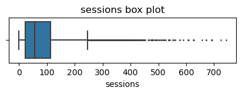

```python
# I examined the 'sessions' field of the dataframe using a Box plot
# This represents the number of occurrences of a user opening the app during the month

plt.figure(figsize=(5,1))
sns.boxplot(x=df['sessions'], fliersize=1)
plt.title('sessions box plot');
```

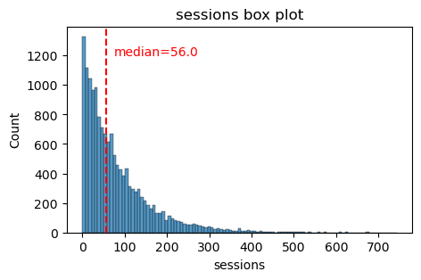

```python
# I further examined the 'sessions' field of the dataframe using a Histogram

plt.figure(figsize=(5,3))
sns.histplot(x=df['sessions'])
median = df['sessions'].median()
plt.axvline(median, color='red', linestyle='--')
plt.text(75,1200, 'median=56.0', color='red')
plt.title('sessions box plot');
```

**Observations:**

> - The sessions variable is a right-skewed distribution with half of the observations having 56 or fewer sessions
> - However, as indicated by the boxplot, some users have more than 700

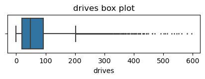

```python
# I examined the 'drive' field of the dataframe using a Box plot
# This represents an occurrence of driving at least 1 km during the month

plt.figure(figsize=(5,1))
sns.boxplot(x=df['drives'], fliersize=1)
plt.title('drives box plot');
```

```python
# I defined a helper function to plot histograms based on the format of the 'sessions' histogram

def histogrammer(column_str, median_text=True, **kwargs):    # **kwargs = any keyword arguments
                                                             # from the sns.histplot() function
    median=round(df[column_str].median(), 1)
    plt.figure(figsize=(5,3))
    ax = sns.histplot(x=df[column_str], **kwargs)
    plt.axvline(median, color='red', linestyle='--')
    if median_text==True:
        ax.text(0.25, 0.85, f'median={median}', color='red',
            ha='left', va='top', transform=ax.transAxes)
    else:
        print('Median:', median)
    plt.title(f'{column_str} histogram');
```

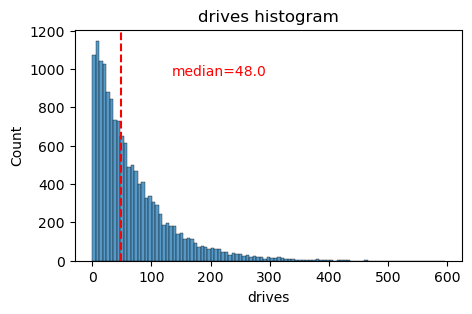

```python
# Histogram
histogrammer('drives')
```

**Observations:**

> - The drives information follows a distribution similar to the sessions variable
> - It is right-skewed, approximately log-normal, with a median of 48
> - However, some drivers had over 400 drives in the last month

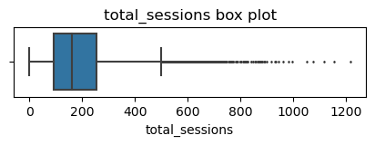

```python
# I then plotted a model estimate of the total number of sessions since a user has onboarded

# Box plot
plt.figure(figsize=(5,1))
sns.boxplot(x=df['total_sessions'], fliersize=1)
plt.title('total_sessions box plot');
```

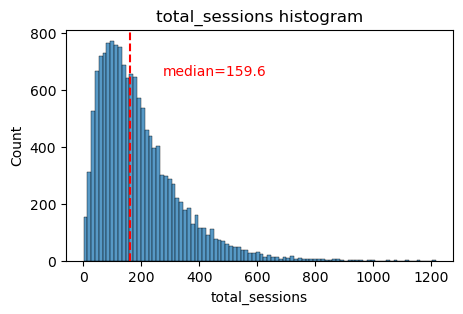

```python
# Histogram
histogrammer('total_sessions')
```

**Observations:**

> - The total_sessions is a right-skewed distribution
> - The median total number of sessions is 159.6.
> - This is interesting information because, if the median number of sessions in the last month was 56 and the median total sessions was ~160, then it seems that a large proportion of a user's (estimated) total drives might have taken place in the last month
> - This is something I'll examine more closely later.

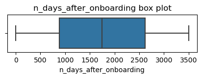

```python
# n_days_after_onboarding represents the number of days since a user signed up for the app

# Box plot
plt.figure(figsize=(5,1))
sns.boxplot(x=df['n_days_after_onboarding'], fliersize=1)
plt.title('n_days_after_onboarding box plot');
```

```
Median: 1741.0
```

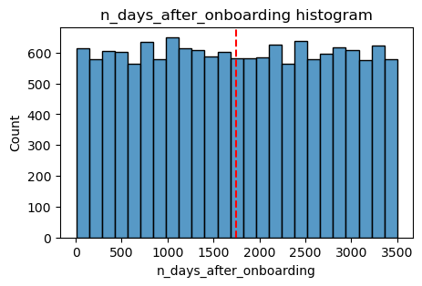

```python
# Histogram
histogrammer('n_days_after_onboarding', median_text=False)
```

> - The total user tenure (i.e., number of days since onboarding) is a uniform distribution with values ranging from near-zero to 3,500 or (9.5 years)

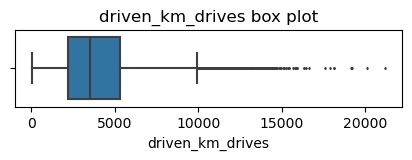

```python
# driven_km_drives represents total kilometers driven during the month

# Box plot
plt.figure(figsize=(5,1))
sns.boxplot(x=df['driven_km_drives'], fliersize=1)
plt.title('driven_km_drives box plot');
```

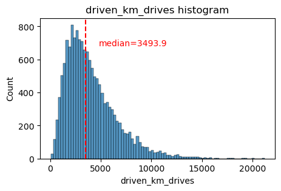

```python
# Histogram
histogrammer('driven_km_drives')
```

**Observation:**

> - The number of drives driven in the last month per user is a right-skewed distribution with half the users driving under 3,495 kilometers

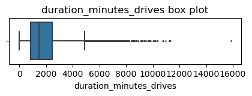

```python
# duration_minutes_drives represents total duration driven in minutes during the month

# Box plot
plt.figure(figsize=(5,1))
sns.boxplot(x=df['duration_minutes_drives'], fliersize=1)
plt.title('duration_minutes_drives box plot');
```

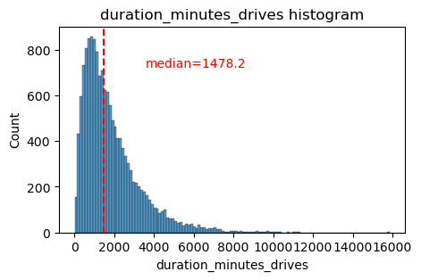

```python
# Histogram
histogrammer('duration_minutes_drives')
```

**Observations:**

> - The duration_minutes_drives variable has a heavily skewed right tail
> - Half of the users drove less than 1,478 minutes (~25 hours), but some users clocked over 250 hours over the month

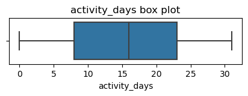

```python
# activity_days represents the number of days the user opens the app during the month

# Box plot
plt.figure(figsize=(5,1))
sns.boxplot(x=df['activity_days'], fliersize=1)
plt.title('activity_days box plot');
```

```
Median: 16.0
```

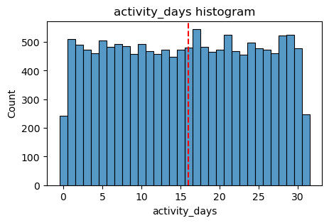

```python
# Histogram
histogrammer('activity_days', median_text=False, discrete=True)
```

**Observations:**

> - Within the last month, users opened the app a median of 16 times
> - The box plot reveals a centered distribution
> - The histogram shows a nearly uniform distribution of ~500 people opening the app on each count of days however, there are ~250 people who didn't open the app at all and ~250 people who opened the app every day of the month
> - This distribution is noteworthy because it does not mirror the sessions distribution

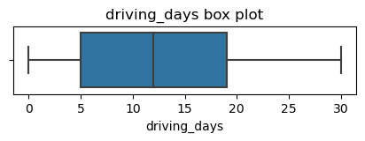

```python
# driving_days represents the number of days the user drives (at least 1 km) during the month

# Box plot
plt.figure(figsize=(5,1))
sns.boxplot(x=df['driving_days'], fliersize=1)
plt.title('driving_days box plot');
```

```
Median: 12.0
```

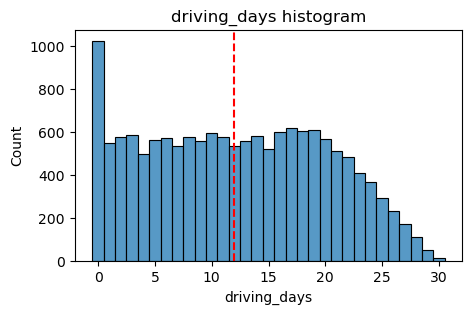

```python
# Histogram
histogrammer('driving_days', median_text=False, discrete=True)
```

**Observations:**

> - The number of days users drove each month is almost uniform, and it largely correlates with the number of days they opened the app that month, except the driving_days distribution which tails off on the right however, there were almost twice as many users (~1,000 vs. ~550) who did not drive at all during the month.
> - This might seem counterintuitive when considered together with the information from activity_days that variable had ~500 users opening the app on each of most of the day counts, but there were only ~250 users who did not open the app at all during the month and ~250 users who opened the app every day.
> - I Flagged this for further investigation later

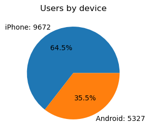

```python
# device represents the type of device a user starts a session with
# Based on my experience, a good plot for a binary categorical variable is a pie chart

# Pie chart
fig = plt.figure(figsize=(3,3))
data=df['device'].value_counts()
plt.pie(data,
        labels=[f'{data.index[0]}: {data.values[0]}',
                f'{data.index[1]}: {data.values[1]}'],
        autopct='%1.1f%%'
        )
plt.title('Users by device');
```

**Observations:**

> - There are nearly twice as many iPhone users as Android users represented in this data
> - Label represents the binary target variable (“retained” vs “churned”) for if a user has churned anytime during the course of the month
> - This is also a categorical variable, which I plotted as a pie chart as well

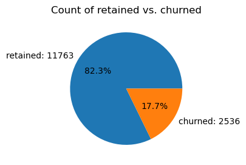

```python
# Pie chart
fig = plt.figure(figsize=(3,3))
data=df['label'].value_counts()
plt.pie(data,
        labels=[f'{data.index[0]}: {data.values[0]}',
                f'{data.index[1]}: {data.values[1]}'],
        autopct='%1.1f%%'
        )
plt.title('Count of retained vs. churned');
```

**Observation:**

> - Less than 18% of the users churned
> - Since both driving_days and activity_days represent counts of days over a month and they're also closely related, I plotted them together on a single histogram.

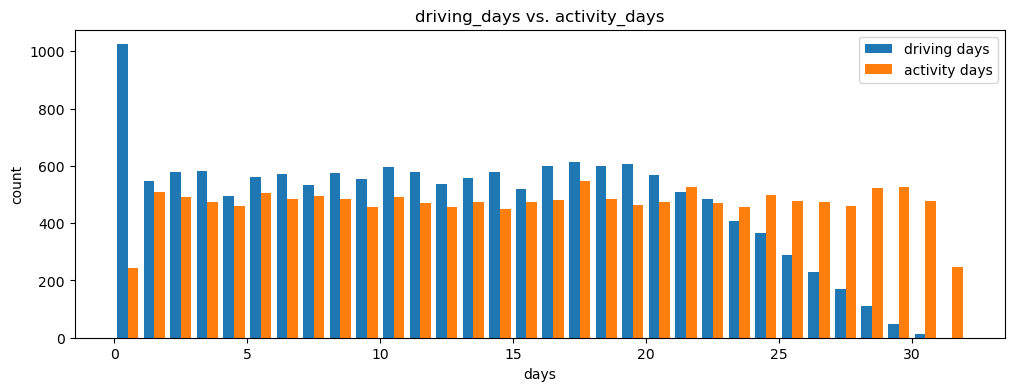

```python
# This histogram for each, has a bar representing the counts of driving_days and activity_days

plt.figure(figsize=(12,4))
label=['driving days', 'activity days']
plt.hist([df['driving_days'], df['activity_days']],
         bins=range(0,33),
         label=label)
plt.xlabel('days')
plt.ylabel('count')
plt.legend()
plt.title('driving_days vs. activity_days');
```

**Observations:**

> - This represents data that might seem counterintuitive
> - Why are there fewer people who didn't use the app at all during the month? and more people who didn't drive at all during the month?
> - Perhaps its just illustrative of the fact that, while these variables are related to each other, they're not the same people probably just opened the app more than they use the app to drive maybe to check drive times or route information, to update settings, or even just opened the app by mistake.
> - This alerts me to contact the data team to get more information about this, especially because it seems that the number of days in the month are not the same between variables.

```python
# I then decided th confirm the maximum number of days for each variable
print(df['driving_days'].max())
print(df['activity_days'].max())
```

```
30
31
```

**Observation:**

> - It's true, although it's possible that not a single user drove all 31 days of the month, it's highly unlikely, considering there are 15,000 people represented in this dataset.

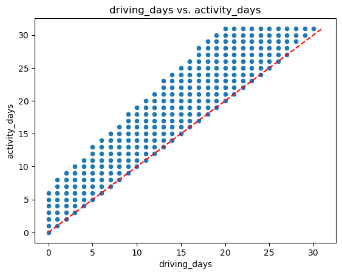

```python
# I decided that another way to check the validity of these variables is to plot a simple scatter plot
# with the x-axis representing one variable and the y-axis representing the other

# Scatter plot
sns.scatterplot(data=df, x='driving_days', y='activity_days')
plt.title('driving_days vs. activity_days')
plt.plot([0,31], [0,31], color='red', linestyle='--');
```

**Observations:**

> - I noticed that there is a theoretical limit
> - If you use the app to drive, then by definition it must count as a day-use as well
> - This means there cannot be more drive-days than activity-days
> - No samples within this dataset violate this rule

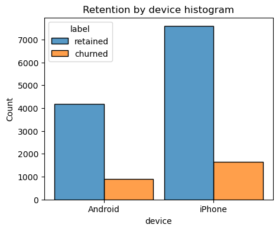

```python
# Retention by device investigation
# I plotted a histogram that 4 bars
# one for each device-label combination—to show how many
# iPhone users were retained/churned and how many Android users were retained/churned.

plt.figure(figsize=(5,4))
sns.histplot(data=df,
             x='device',
             hue='label',
             multiple='dodge',
             shrink=0.9
             )
plt.title('Retention by device histogram');
```

**The proportion of churned users to retained users is consistent between device types**

> - Retention by kilometers driven per driving day
> - Within the inspect and analyze data notebook I previously created, I discovered that the median distance driven per driving day last month for users who churned was 697.54 km, versus 289.55 km for people who did not churn
> - I'll now examine this further
> - To start I created a new column in df called km_per_driving_day which represents the mean distance driven per driving day for each user
> - I then called the describe() method on the new column

```python
# `km_per_driving_day` column
df['km_per_driving_day'] = df['driven_km_drives'] / df['driving_days']

# `describe()` on the new column
df['km_per_driving_day'].describe()
```

```
count    1.499900e+04
mean              inf
std               NaN
min      3.022063e+00
25%      1.672804e+02
50%      3.231459e+02
75%      7.579257e+02
max               inf
Name: km_per_driving_day, dtype: float64
```

**Observations:**

> - I immediately noticed that the mean and max values are infinity
> - I also noticed the standard deviation is NaN
> - This must be the result of there being values of zero in the driving_days column
> - I recall that Pandas imputes a value of infinity in the corresponding rows of the new column because division by zero is undefined

```python
# I then converted these values from infinity to zero using np.inf to refer to a value of infinity
# I then called describe() again on the km_per_driving_day column to verify that it worked

# Convert infinite values to zero
df.loc[df['km_per_driving_day']==np.inf, 'km_per_driving_day'] = 0

# Confirm that it worked
df['km_per_driving_day'].describe()
```

```
count    14999.000000
mean       578.963113
std       1030.094384
min          0.000000
25%        136.238895
50%        272.889272
75%        558.686918
max      15420.234110
Name: km_per_driving_day, dtype: float64
```

**Observations:**

> - The maximum value is 15,420 kilometers per drive day
> - This is physically impossible as driving 100 km/hour for 12 hours is 1,200 km and it's very unlikely people averaged more than this each day they drove
> - I then decided to disregard rows where the distance in this column was greater than 1,200 km

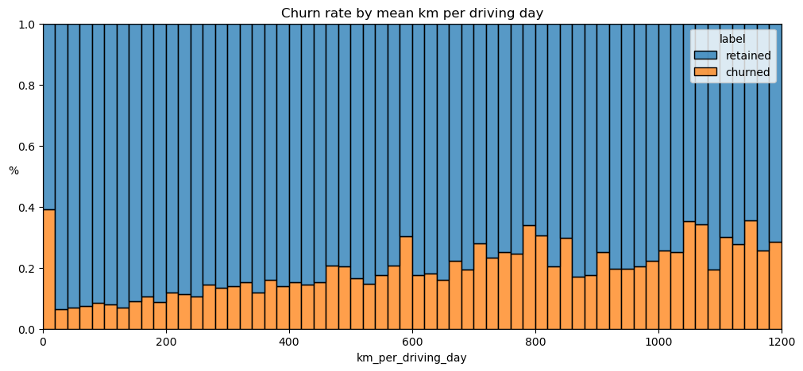

```python
# I then plotted an updated histogram of the new km_per_driving_day column
# this disregarded users with values greater than 1,200 km

plt.figure(figsize=(12,5))
sns.histplot(data=df,
             x='km_per_driving_day',
             bins=range(0,1201,20),
             hue='label',
             multiple='fill')
plt.ylabel('%', rotation=0)
plt.title('Churn rate by mean km per driving day');
```

**Observations:**

> - The churn rate tends to increase as the mean daily distance driven increases, confirming what I found previously
> - It will be worth investigating further reasons for long-distance users to discontinue using the app

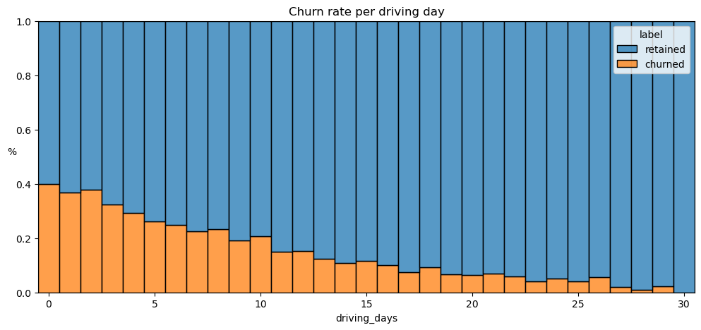

```python
# I then explored the churn rate per number of driving days

plt.figure(figsize=(12,5))
sns.histplot(data=df,
             x='driving_days',
             bins=range(1,32),
             hue='label',
             multiple='fill',
             discrete=True)
plt.ylabel('%', rotation=0)
plt.title('Churn rate per driving day');
```

**Observations:**

> - The churn rate is highest for people who didn't use Waze much during the last month
> - The more times they used the app, the less likely they were to churn while 40% of the users who didn't use the app at all last month churned
> - No one who used the app for 30 days churned
> - This insight likely indicates that users are not Dissatisfied with the app

**Next, I created a proportion of sessions that occurred in the last month**

> - To do so, I created a new column called percent_sessions_in_last_month
> - This represents the percentage of each user's total sessions that were logged in their last month of use

```python
df['percent_sessions_in_last_month'] = df['sessions'] / df['total_sessions']
```

```python
# I used median() to caluclate the median value of the new column

df['percent_sessions_in_last_month'].median()
```

```
0.42309702992763176
```

```
Median: 0.4
```

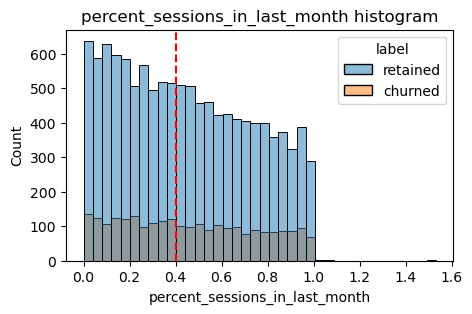

```python
# I then created a histogram depicting the distribution of values in this new column

histogrammer('percent_sessions_in_last_month',
             hue=df['label'],
             multiple='layer',
             median_text=False)
```

```python
# I then checked the median value of the n_days_after_onboarding variable

df['n_days_after_onboarding'].median()
```

```
1741.0
```

**Observation:**

> - Half of the people in the dataset had 40% or more of their sessions in just the last month, yet the overall median time since onboarding is almost five years (4.77 years)

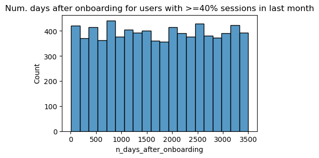

```python
# I then made a histogram of n_days_after_onboarding for just the users who had 40%
# or more of their total sessions in the last month

data = df.loc[df['percent_sessions_in_last_month']>=0.4]
plt.figure(figsize=(5,3))
sns.histplot(x=data['n_days_after_onboarding'])
plt.title('Num. days after onboarding for users with >=40% sessions in last month');
```

**Observations:**

> - This displays a uniform distribution for users with 40% or more of their total sessions occurring in just the last month
> - This is worth asking the data team why so many long-time users suddenly used the app so much in the last month

```python
# Handling outliers as previously mentioned
# The box plots previously indicated that many of these variables have outliers
# These outliers do not seem to be data entry errors; they are present because of the right-skewed distributions
# I'll impute outlying data with more reasonable values
# To do this, I set a threshold based on a percentile of the distribution by creating a function

def outlier_imputer(column_name, percentile):
    # Calculate threshold
    threshold = df[column_name].quantile(percentile)
    # Impute threshold for values > than threshold
    df.loc[df[column_name] > threshold, column_name] = threshold

    print('{:>25} | percentile: {} | threshold: {}'.format(column_name, percentile, threshold))
```

> - I then applied this function to the following columns:

`sessions`, `drives`, `total_sessions`, `driven_km_drives`, `duration_minutes_drives`

```python
for column in ['sessions', 'drives', 'total_sessions',
               'driven_km_drives', 'duration_minutes_drives']:
               outlier_imputer(column, 0.95)
```

```
                 sessions | percentile: 0.95 | threshold: 243.0
                   drives | percentile: 0.95 | threshold: 201.0
           total_sessions | percentile: 0.95 | threshold: 454.3632037399997
         driven_km_drives | percentile: 0.95 | threshold: 8889.7942356
  duration_minutes_drives | percentile: 0.95 | threshold: 4668.899348999998
```

```python
# I called the describe() to confirm if my change worked

df.describe()
```

|  | ID | sessions | drives | total_sessions | n_days_after_onboarding | total_navigations_fav1 | total_navigations_fav2 | driven_km_drives | duration_minutes_drives | activity_days | driving_days | km_per_driving_day | percent_sessions_in_last_month |
| --- | --- | --- | --- | --- | --- | --- | --- | --- | --- | --- | --- | --- | --- |
| count | 14999.000000 | 14999.000000 | 14999.000000 | 14999.000000 | 14999.000000 | 14999.000000 | 14999.000000 | 14999.000000 | 14999.000000 | 14999.000000 | 14999.000000 | 14999.000000 | 14999.000000 |
| mean | 7499.000000 | 76.568705 | 64.058204 | 184.031320 | 1749.837789 | 121.605974 | 29.672512 | 3939.632764 | 1789.647426 | 15.537102 | 12.179879 | 578.963113 | 0.449255 |
| std | 4329.982679 | 67.297958 | 55.306924 | 118.600463 | 1008.513876 | 148.121544 | 45.394651 | 2216.041510 | 1222.705167 | 9.004655 | 7.824036 | 1030.094384 | 0.286919 |
| min | 0.000000 | 0.000000 | 0.000000 | 0.220211 | 4.000000 | 0.000000 | 0.000000 | 60.441250 | 18.282082 | 0.000000 | 0.000000 | 0.000000 | 0.000000 |
| 25% | 3749.500000 | 23.000000 | 20.000000 | 90.661156 | 878.000000 | 9.000000 | 0.000000 | 2212.600607 | 835.996260 | 8.000000 | 5.000000 | 136.238895 | 0.196221 |
| 50% | 7499.000000 | 56.000000 | 48.000000 | 159.568115 | 1741.000000 | 71.000000 | 9.000000 | 3493.858085 | 1478.249859 | 16.000000 | 12.000000 | 272.889272 | 0.423097 |
| 75% | 11248.500000 | 112.000000 | 93.000000 | 254.192341 | 2623.500000 | 178.000000 | 43.000000 | 5289.861262 | 2464.362632 | 23.000000 | 19.000000 | 558.686918 | 0.687216 |
| max | 14998.000000 | 243.000000 | 201.000000 | 454.363204 | 3500.000000 | 1236.000000 | 415.000000 | 8889.794236 | 4668.899349 | 31.000000 | 30.000000 | 15420.234110 | 1.530637 |

# **PACE:** Execute

**I've learned from this dataset...**

> - There is missing data in the user churn label, so I might need further data processing before further analysis
> - There are many outlying observations for drives, so I might consider a variable transformation to stabilize the variation
> - The number of drives and the number of sessions are both strongly correlated, so they might provide redundant information when I incorporate both in a model
> - On average, retained users have fewer drives than churned users

**My additional questions are...**

> - How did the missing values in the user churn label arise?
> - Who are the users with an extremely large number of drives? Are they ridesharing drivers or commercial drivers?
> - Why do retained users have fewer drives than churned users?
> - Is it because churned users have a longer history of using the Waze app?
> - What is the user demographic for retained users and churned users?

**My client would likely want to know...**

> - What are the key variables associated with user churn?
> - Can we implement policies to reduce user churn?
> - To attempt an answer here, I added to code blocks to do additional EDA

```python
df['monthly_drives_per_session_ratio'] = (df['drives']/df['sessions'])
```

```python
df.head(10)
```

|  | ID | label | sessions | drives | total_sessions | n_days_after_onboarding | total_navigations_fav1 | total_navigations_fav2 | driven_km_drives | duration_minutes_drives | activity_days | driving_days | device | km_per_driving_day | percent_sessions_in_last_month | monthly_drives_per_session_ratio |
| --- | --- | --- | --- | --- | --- | --- | --- | --- | --- | --- | --- | --- | --- | --- | --- | --- |
| 0 | 0 | retained | 243 | 201 | 296.748273 | 2276 | 208 | 0 | 2628.845068 | 1985.775061 | 28 | 19 | Android | 138.360267 | 0.953670 | 0.827160 |
| 1 | 1 | retained | 133 | 107 | 326.896596 | 1225 | 19 | 64 | 8889.794236 | 3160.472914 | 13 | 11 | iPhone | 1246.901868 | 0.406856 | 0.804511 |
| 2 | 2 | retained | 114 | 95 | 135.522926 | 2651 | 0 | 0 | 3059.148818 | 1610.735904 | 14 | 8 | Android | 382.393602 | 0.841186 | 0.833333 |
| 3 | 3 | retained | 49 | 40 | 67.589221 | 15 | 322 | 7 | 913.591123 | 587.196542 | 7 | 3 | iPhone | 304.530374 | 0.724968 | 0.816327 |
| 4 | 4 | retained | 84 | 68 | 168.247020 | 1562 | 166 | 5 | 3950.202008 | 1219.555924 | 27 | 18 | Android | 219.455667 | 0.499266 | 0.809524 |
| 5 | 5 | retained | 113 | 103 | 279.544437 | 2637 | 0 | 0 | 901.238699 | 439.101397 | 15 | 11 | iPhone | 81.930791 | 0.404229 | 0.911504 |
| 6 | 6 | retained | 3 | 2 | 236.725314 | 360 | 185 | 18 | 5249.172828 | 726.577205 | 28 | 23 | iPhone | 228.224906 | 0.012673 | 0.666667 |
| 7 | 7 | retained | 39 | 35 | 176.072845 | 2999 | 0 | 0 | 7892.052468 | 2466.981741 | 22 | 20 | iPhone | 394.602623 | 0.221499 | 0.897436 |
| 8 | 8 | retained | 57 | 46 | 183.532018 | 424 | 0 | 26 | 2651.709764 | 1594.342984 | 25 | 20 | Android | 132.585488 | 0.310573 | 0.807018 |
| 9 | 9 | churned | 84 | 68 | 244.802115 | 2997 | 72 | 0 | 6043.460295 | 2341.838528 | 7 | 3 | iPhone | 2014.486765 | 0.343134 | 0.809524 |

**The next steps...**

> - Share my findings with the data team
> - Attempt to get answers to previous questions raised
> - Prepare an executive summary

# Conclusion:

> - Analysis revealed that the overall churn rate is ~17%, this rate is consistent between iPhone users and Android users
> - EDA revealed that users who drive very long distances on their driving days are more likely to churn,but users who drive more often are less likely to churn
> - The reason for this discrepancy is an opportunity for further investigation, and it would be something else to ask the data team about